# Opdracht

Thomas Koops

15 januari 2018

# Inleiding

```r
## defines the root of the project for later use
require("rprojroot") || utils::install.packages("rprojroot")
```

```
## [1] TRUE
```

```r
library(rprojroot)
require("readr") || utils::install.packages("readr")
```

```
## [1] TRUE
```

```r
library(readr)
require("tidyverse") || utils::install.packages("tidyverse")
```

```
## [1] TRUE
```

```r
library("tidyverse")
root <- find_root_file(criterion = is_rstudio_project)


toxref_raw <- read_csv("toxrefdb_nel_lel_noael_loael_summary_AUG2014_FOR_PUBLIC_RELEASE.csv")
#tidy data

#removes uppercases from the variables
toxref_raw <- data.frame(lapply(toxref_raw, function(v) {
  if (is.character(v)) return(tolower(v))
  else return(v)
}))

#removes whitespaces, first it removing leading and trailing whitespaces then replaces all remaining whitespaces with underscores
toxref_raw <- as.data.frame(apply(toxref_raw,2,function(x)trimws(x, which = c("both", "left", "right"))))
toxref_raw <- as.data.frame(apply(toxref_raw,2,function(x)gsub('\\s+', '_',x)))
```

```r
#inspect the integrity of the data

#makes a list of what type of data is in each column and transforms it into a dataframe
df_names <- do.call(rbind.data.frame, lapply(toxref_raw, typeof))
df_names$name <- names(toxref_raw)
df_names <- df_names[,c(2,1)]
colnames(df_names)[2] <- "type"

#summary of each variable that's not a character

no_character_names <- filter(df_names,type != "character")
no_character_toxref <-na.omit(select(toxref_raw, no_character_names$name))
summary_toxref <- lapply(no_character_toxref, summary)
df_summary_toxref <- do.call(rbind.data.frame,lapply(no_character_toxref, summary))
df_summary_toxref <- setNames(df_summary_toxref, c("min","1st_qu", "median", "mean","3rd qu","max"))
df_summary_toxref <- df_summary_toxref[c(1:6)]
df_summary_toxref$name <- no_character_names$name
df_summary_toxref <- df_summary_toxref[,c(7,1:6)]
df_summary_toxref$number <- c(1:53)
#changes df_summary_toxref$min from a scientific notation to a normal notation
df_summary_toxref$min <- as.list(df_summary_toxref$min)

#function that calculates the error for confindence interval with argument column for the no_character_toxref column that is used and percentage for the level of confidence
conf_interval_toxref <- function(column,percentage){
  colu_number <- unlist(subset(df_summary_toxref, name == column, "number"))
  std_dev <- sd(unlist(no_character_toxref[colu_number]))
  n <- count((no_character_toxref[colu_number]))
  error <- qnorm(percentage)*std_dev/sqrt(n)
  return(error)
}
#function that calculates the mean with argument column for the no_character_toxref column used
mean_toxref <- function(column){
  colu_number <- as.numeric(unlist(subset(df_summary_toxref, name == column, "number")))
  mean <- mean(unlist(no_character_toxref[colu_number]),na.rm=TRUE)
  return(mean)
}
#calculating the error for confidence and mean values

conf_interval_values <- t(data.frame(sapply(unlist(df_names[1]), conf_interval_toxref,percentage = 0.95)))
```

[output not shown]

[output cut: 103 more lines]

[output not shown]

```r
#due to a error in the mean_toxref function the following chunks can not be loaded
#mean_values <- t(data.frame(lapply(unlist(df_names[1])), mean_toxref))
#calculating the left and right end of the confidence interval
#left_conf_int <- unlist(unlist(mean_values) - unlist(conf_interval_values))
#right_conf_int <- unlist(unlist(mean_values) + unlist(conf_interval_values))
#adding the left and right end of the confidence interval to df_summary_toxref
#df_summary_toxref$left_conf_inter <- left_conf_int
#df_summary_toxref$right_conf_inter <- right_conf_int
colnames(df_summary_toxref)[colnames(df_summary_toxref)=="left_conf_int.unlist(mean_values) - unlist(conf_interval_values)"] <- "left_conf_inter"
colnames(df_summary_toxref)[colnames(df_summary_toxref)=="right_conf_int.unlist(mean_values) + unlist(conf_interval_values)"] <- "right_conf_inter"
#Summary that shows confidence intervals, max, min, mean, 1st and 3rd quarter and median values
df_summary_toxref
```

```
##                            name  min 1st_qu median mean 3rd qu  max number
## 1                            X1    1      1      1    1      1    1      1
## 2                   chemical_id   43     42     34   33     32   30      2
## 3                chemical_casrn   43     42     34   33     32   30      3
## 4                 chemical_name   43     42     34   33     32   30      4
## 5                 chemical_sets  454    887      7   33   2819   71      5
## 6                   data_source    9     12    727  141   4489    0      6
## 7               entry_status_id 1354   3626    633   20   1354 3626      7
## 8                  entry_status 1354     20   3626  633   1354   20      8
## 9                entry_level_id   15   5618      0   15   5618    0      9
## 10                  entry_level    0   5618     15    0   5618   15     10
## 11                    usability  655   3324    909  296    410   39     11
## 12               usability_desc  655   3324    909  410    296   39     12
## 13                     study_id    3      3      3    3      3    3     13
## 14      source_study_numeric_id 1011     12      8    8      8    6     14
```

[output cut: 39 more lines]

```r
#number of rows
nrow(toxref_raw)
```

```
## [1] 11815
```

```r
#data-type of each variable
df_names
```

```
##                            name    type
## 1                            X1 integer
## 2                   chemical_id integer
## 3                chemical_casrn integer
## 4                 chemical_name integer
## 5                 chemical_sets integer
## 6                   data_source integer
## 7               entry_status_id integer
## 8                  entry_status integer
## 9                entry_level_id integer
## 10                  entry_level integer
## 11                    usability integer
## 12               usability_desc integer
## 13                     study_id integer
## 14      source_study_numeric_id integer
```

[output cut: 39 more lines]

```r
#Selecting, filtering, mutating and summarizing

#selects the columns that will be used
toxref_tidy <- subset(toxref_raw, select=c("X1", "chemical_name","entry_status_id" , "usability_desc","admin_method","admin_route" ,"study_type",  "species","effect_category","lel_qualifier","lel_dose","nel_qualifier","nel_dose","loael_qualifier","loael_dose","noael_qualifier","noael_dose"))

#bodyweight dataframe
toxref_bw <- subset(toxref_raw, select=c("X1", "species","strain"))

#adding body weight to each of the species (Environmental Protection Division, 1996)
toxref_bw$body_weight <- ifelse(toxref_bw$species=="guinea-pig", 700,
        ifelse(toxref_bw$species=="mink", 1000,
        ifelse(toxref_bw$species=="mouse", 60,
        ifelse(toxref_bw$species=="rabbit", 3000,
        ifelse(toxref_bw$species=="rat", 400,
        ifelse(toxref_bw$species=="dog", 35000,
                        NA  ))))))
toxref_tidy$body_weight <- toxref_bw$body_weight
```

```r
#corralation body weight and lel, nel, loael, noael with the most frequent chemical


#most frequent chemical
most_freq_chem <- rownames(data.frame(tail(sort(table(toxref_tidy$chemical_name)),1)))
#how many times the chemical is used between species
table(toxref_tidy$species, toxref_tidy$chemical_name == most_freq_chem)
```

```
##
##              FALSE TRUE
##   dog         1470   16
##   guinea-pig     3    0
##   hamster       37    0
##   mink           3    0
##   mouse       2089   13
##   primate       77    0
##   rabbit      1335   11
##   rat         6717   44
```

```r
toxref_most_freq_chem <- subset(toxref_tidy, subset = toxref_tidy$chemical_name == most_freq_chem)

toxref_bw_dose <- subset(toxref_most_freq_chem, select=c("lel_dose", "nel_dose","loael_dose","noael_dose","body_weight"))
#to prevent outliers values above the 10000g will be discarded
toxref_bw_dose <- subset(toxref_bw_dose, subset = toxref_bw_dose$body_weight < 10000)
toxref_bw_dose <-
   toxref_bw_dose %>%
  gather("lel_dose", "nel_dose","loael_dose","noael_dose", key="dose_type", value = "dose")
```

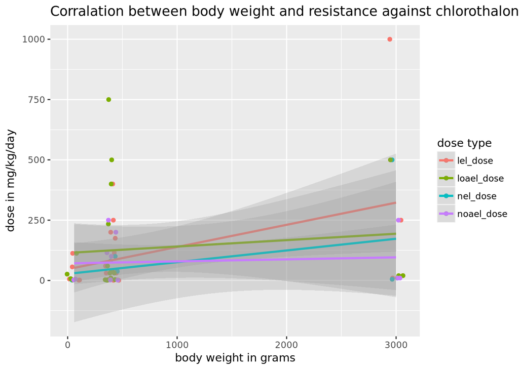

```r
toxref_bw_dose[toxref_bw_dose == "null"] <- NA
toxref_bw_dose <- na.omit(toxref_bw_dose)
toxref_bw_dose$dose <- as.double(toxref_bw_dose$dose)
ggplot(data = toxref_bw_dose) +
  geom_point(mapping=aes(jitter(x=toxref_bw_dose$body_weight, 1),y=toxref_bw_dose$dose, color = toxref_bw_dose$dose_type)) +
  geom_smooth(mapping=aes(x = toxref_bw_dose$body_weight,y=toxref_bw_dose$dose, color = toxref_bw_dose$dose_type), method = "lm", alpha = 0.25)+ xlab ("body weight in grams") + ylab("dose in mg/kg/day")+ ggtitle("Corralation between body weight and resistance against chlorothalonil")+ labs(color = "dose type")
```

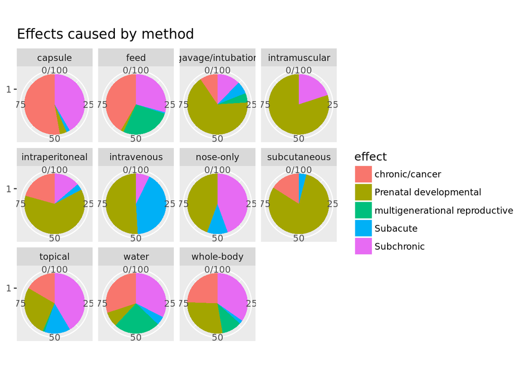

```r
toxref_admin_effect <- subset(toxref_tidy, select=c("admin_method", "study_type","admin_route"))

#correlation between administration method and the effect it had
admin_effect_count <- function(method){
  count <- table(toxref_admin_effect$study_type, toxref_admin_effect$admin_method== as.character(method))[,2]
  effect <- rownames(table(toxref_admin_effect$study_type,toxref_admin_effect$admin_method==as.character(method)))
  return <- data.frame(method,effect,count)
  rownames(return) <- c()
  return(return)
}
#code below doesn't seem to work so it will be done manually
#toxref_admin_effect_count <- data.frame(lapply(as.list(data.frame(unique(toxref_admin_effect_sample$admin_method))), admin_effect_count))
#not_reported and [not_specified] were left out because they were unable to say anything about the effect of a administration method
toxref_admin_effect_count <- rbind(
  admin_effect_count("capsule"),
  admin_effect_count("feed"),
  admin_effect_count("gavage/intubation"),
  admin_effect_count("intramuscular"),
  admin_effect_count("intraperitoneal"),
  admin_effect_count("intravenous"),
  admin_effect_count("nose-only"),
  admin_effect_count("subcutaneous"),
  admin_effect_count("topical"),
  admin_effect_count("water"),
  admin_effect_count("whole-body")
)
total_freq <- data.frame(table(toxref_admin_effect$admin_method))
assign_freq <- function(method){
   freq <- filter(total_freq, as.character(method)==total_freq$Var1)[,2]
   return(freq)
}
all_freq <- t(data.frame(lapply(toxref_admin_effect_count$method, assign_freq)))
toxref_admin_effect_count$freq_method <- all_freq
toxref_admin_effect_count$percentage_effect <- toxref_admin_effect_count$count/toxref_admin_effect_count$freq_method*100

ggplot(toxref_admin_effect_count, aes(x =factor(1), y = percentage_effect, fill = factor(effect, labels = c("chronic/cancer","Prenatal developmental","multigenerational reproductive","Subacute","Subchronic")))) +
    geom_bar(stat = "identity", width = 1) +
   scale_x_discrete(NULL, expand = c(0,0)) +
    scale_y_continuous(NULL, expand = c(0,0)) +
    coord_polar(theta = "y") +
    facet_wrap(~method)+
    ylab("percentage")+
    ggtitle("Effects caused by method")+
    labs(fill ="effect")
```

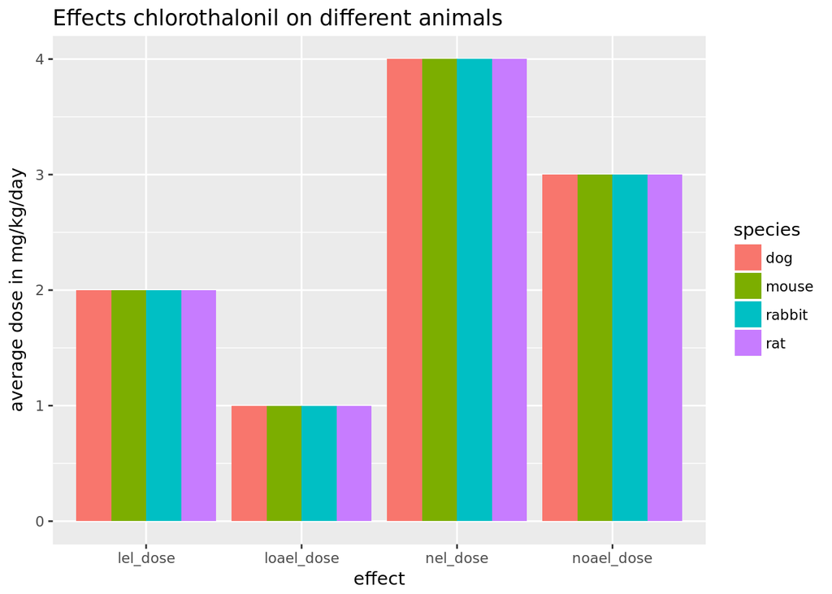

```r
#looking at the lel, loael, nel and noael dose of different animals for the chemical chlorothalonil
dose_levels <- function(species){
spec_set <- filter(toxref_tidy, toxref_tidy$species==as.character(species))
chem <- filter(spec_set, spec_set$chemical_name=="chlorothalonil")
chem <- subset(chem, select=c("lel_dose", "nel_dose","loael_dose","noael_dose"))
average <- data.frame(rbind(c(mean(as.numeric(chem$lel_dose), na.rm = TRUE),"lel_dose"),
               c(mean(as.numeric(chem$nel_dose), na.rm = TRUE),"nel_dose"),
               c(mean(as.numeric(chem$loael_dose), na.rm = TRUE),"loael_dose"),
               c(mean(as.numeric(chem$noael_dose), na.rm = TRUE),"noael_dose")))

average$species <- as.character(species)

return(average)
}
#dogs, mice, rabbits and rats have values for chlorothalonil
toxref_species_chloro<- rbind(dose_levels("dog"),
                              dose_levels("mouse"),
                              dose_levels("rabbit"),
                              dose_levels("rat"))
colnames(toxref_species_chloro) <- c("average_dose","dose_type","species")
toxref_species_chloro$average_dose <- c(toxref_species_chloro$average_dose)

ggplot(data = toxref_species_chloro,mapping=aes(x=dose_type, y=average_dose, fill=species)) +
  geom_bar(stat = "identity", position=position_dodge())+ xlab ("effect") + ylab("average dose in mg/kg/day")+ ggtitle("Effects chlorothalonil on different animals")
```

#Resultaten Bij de eerste grafiek (Corralation between body weight and resistance against chlorothanolonil) was er voor elk dier soort een geschat gewicht toegevoegd op basis van informatie van het Enviormental Protection division en gekeken of het lichaamsgewicht de lel/nel/loael en noael dosissen zou verhogen. Wel is in de grafiek een helling te zien maar ook is de spreiding erg groot, wat te zien is aan het grote grijze gebied rond de lijnen. Bij de tweede grafiek (Effects caused by method) was er voor elke administratie methode onderzocht welke effecten het meest voorkwamen. Een cirkeldiagram werd hiervoor gemaakt waarbij elke administratie methode een eigen cirkel heeft waarbij aangegeven staat het percentage van elk effect dat plaats vond. Bij de derde grafiek (Effects chlorothalonil on different animals) was er onderzocht bij welke doseringen verschillende dieren effecten begonnen te krijgen. Hierbij was door een fout in de code die niet op tijd gemaakt kon worden de dosering niveaus van alle dieren hetzelfde. Door deze fout is de y-as ook verkeerd gelabeld. Wel is te zien dat de lel dosering (1119 mg/kg/dag) boven de loael dosering (1045 mg/kg/dag) ligt, hetzelfde geld voor de nel (856 mg/kg/dag) en noael (765 mg/kg/dag) doseringen. Omdat lel (lowest effect level) altijd voor loael (lowest observed adverse effect level) komt en nel (no effect level) altijd voor noael (no observed adverse effect level) komt. Dit kan misschien het gevolg zijn van foute codering.

# Conclusie

In de eerste grafiek was het doel te vinden of er een correlatie tussen lichaamsgewicht en weerstand tegen chemicaliën is. Hoewel er de ijklijnen wel een positieve helling hadden kon er door de grote spreiding tussen de verschillende observaties niet met zekerheid gezegd worden of er inderdaad een correlatie tussen is. In vervolg onderzoek zou er uit gezocht kunnen worden waar deze grote spreiding vandaan komt en deze variabele eventueel mee te nemen in de grafiek In de tweede grafiek was het doel om de effecten van verschillende administratie methoden te visualiseren. Hierbij is wel het probleem dat allerlei verschillende chemicaliën gebruikt werden tussen de administratie methodes waardoor er een onzekere variabele tussen zit. In vervolg onderzoek kan gekeken worden om veel data van één chemicalie met verschillende administratie methodes toe te passen. Bij de derde grafiek was het doel om minimale dosissen te vinden voordat chloorthalonil (schadelijke) effecten veroorzaakt bij verschillende dieren. Hierbij was er een fout in de code waardoor de dosis waarden van alle dieren gelijk waren en de y-as niet correct werd. Deze problemen zullen eerst opgelost moeten worden voordat er echt een conclusie uit getrokken kan worden.

# Referenties

Enviormental Protection division (1996). ANIMAL WEIGHTS and their FOOD AND WATER REQUIREMENTS. Retrieved from http://www.env.gov.bc.ca/wat/wq/reference/foodandwater.html